# “Peer assessment:1”

## Loading and preprocessing data

### Load data

```r
setwd("C:/Users/nitin/Desktop")
activity<- read.csv("activity.csv")
head(activity)
```

```
##   steps      date interval
## 1    NA 10/1/2012        0
## 2    NA 10/1/2012        5
## 3    NA 10/1/2012       10
## 4    NA 10/1/2012       15
## 5    NA 10/1/2012       20
## 6    NA 10/1/2012       25
```

### Transform the date attribute into actual date format

```r
activity$date<- as.Date(as.character(activity$date), format="%m/%d/%Y")
head(activity)
```

```
##   steps       date interval
## 1    NA 2012-10-01        0
## 2    NA 2012-10-01        5
## 3    NA 2012-10-01       10
## 4    NA 2012-10-01       15
## 5    NA 2012-10-01       20
## 6    NA 2012-10-01       25
```

```r
totalstep<- aggregate(steps~date,activity,sum,na.rm=TRUE)
```

### 1.Make a histogram of the total number of steps taken each day.

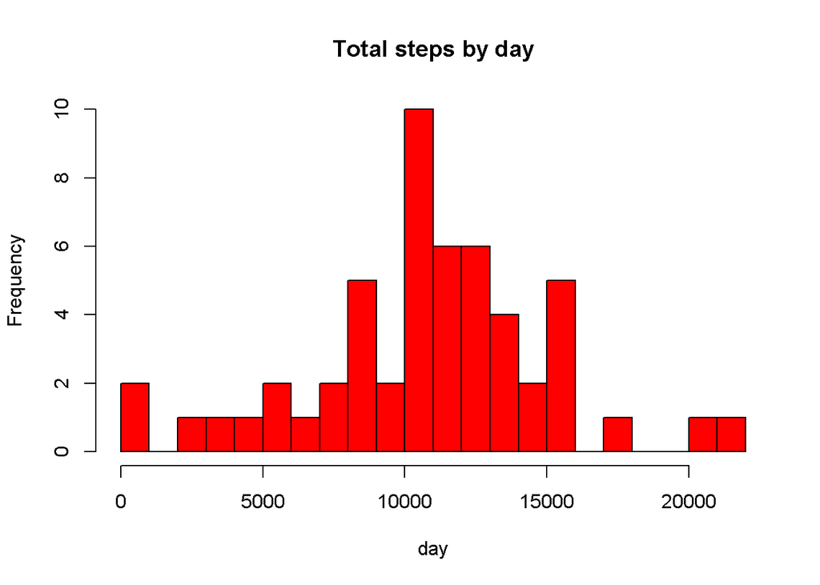

```r
hist(totalstep$steps, breaks=25, main = "Total steps by day", xlab = "day", col = "red")
```

```r
totalstepmean<- mean(totalstep$steps)
totalstepmedian<- median(totalstep$steps)
```

## What is the average daily activity pattern?

### 1. calculate avraege steps at 5min interval per day

```r
mean1<- aggregate(steps~interval, data=activity,FUN=mean,na.rm=TRUE)
```

### 2. time series plot for mean step at every 5 min interval

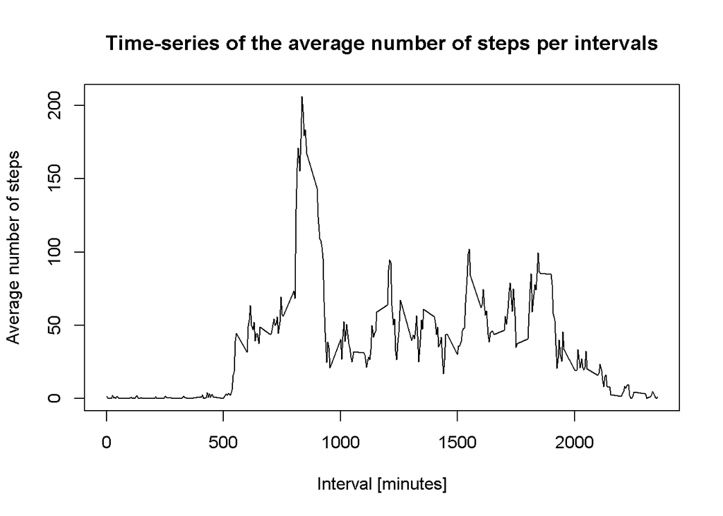

```r
plot(mean1$interval,mean1$steps,type="l",xlab="Interval [minutes]",
     ylab="Average number of steps",
     main="Time-series of the average number of steps per intervals")
```

```r
maxmeanstep<- mean1[mean1$steps==max(mean1$steps),]
```

## Imputing missing values

### 1. Calculate and report the total number of missing values in the dataset

```r
napos<- which(is.na(activity$steps))
length(napos)
```

```
## [1] 2304
```

### 2.Devise a strategy for filling in all of the missing values in the dataset and mae new dataset with missing value filled in.

```r
steps1<- activity$steps
f<- function(steps){m<- mean(steps, na.rm=TRUE)
steps[is.na(steps)]<- m
steps}
imputestep<- f(steps1)
imputeactivity<- cbind(imputestep,activity[,2:3])
```

### 3.Make a histogram of the total number of steps taken each day.

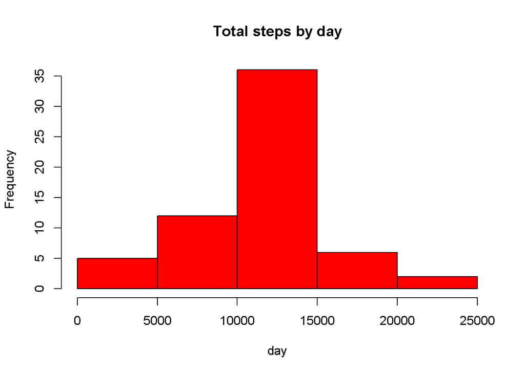

```r
totalstep<- aggregate(imputestep~date,imputeactivity,sum,na.rm=TRUE)
hist(totalstep$imputestep,  main = "Total steps by day", xlab = "day", col = "red")
```

```r
mean<-mean(imputeactivity$imputestep)
meadian<- median(imputeactivity$imputestep)
```

## Differences in activity pattern on weekdays and weekends

### Create a new factor variable in the dataset with two levels - “weekday” and “weekend”

```r
imputeactivity$daytype<- weekdays(imputeactivity$date)
D1<- imputeactivity$daytype=="Saturday" |imputeactivity$daytype=="Sunday"
imputeactivity$daytype[D1]<- "weekend"
imputeactivity$daytype[!D1]<- "weekday"
f1<- factor(imputeactivity$daytype)
```

### 6. time series plot of the 5-minute interval (x-axis) and the average number of steps taken, averaged across all weekday days or weekend days

```r
final<- aggregate(imputeactivity$imputestep,by=list( imputeactivity$daytype,imputeactivity$interval), mean)
names(final) <- c("daytype","interval","mean")
library(lattice)
```

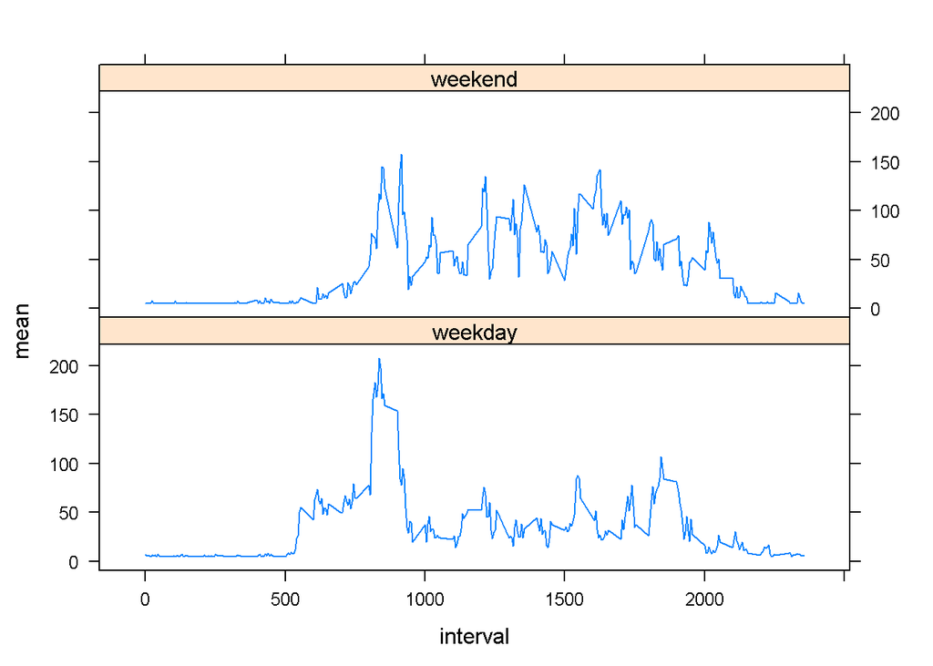

```r
xyplot(mean~interval|daytype, final, type="l",layout=c(1,2))
```